# Incorporating individual variation in animal movement models

Explore data and sampling sequences

# Overall description

We have used the data collected by Kimberly Holbrook for her studies on toucan home ranges and movement patterns (Holbrook 2011). We are starting the original raw data here. Previous work used clean data, as is shown in the `raw-data/newpointlocs.R`, by restricting the individuals to those with a minimum of 40 observations and locations collected in intervals from 15 to 90 minutes in multiples of 15 minutes. As shown in previous studies (Holbrook, Loiselle, and others 2007), the distances traveled by toucans in 15-30 minutes represent the most probable distances for seed dispersal. Due to data collection constraints, locations could not be obtained every 15 minutes, and birds were sometimes located at greater time intervals. Our goal in this section is to explore the raw data again, and use a probabilistic approach that will characterize the pattern of distances moved, and use these probability distributions to later randomly sample distances from.

We can visualize the locations for each of the individuals tagged. The two separate groups represent the two locations considered: Yasuni Biosphere Reserve (upper left) and Tiputini Biodiversity Station (lower right).

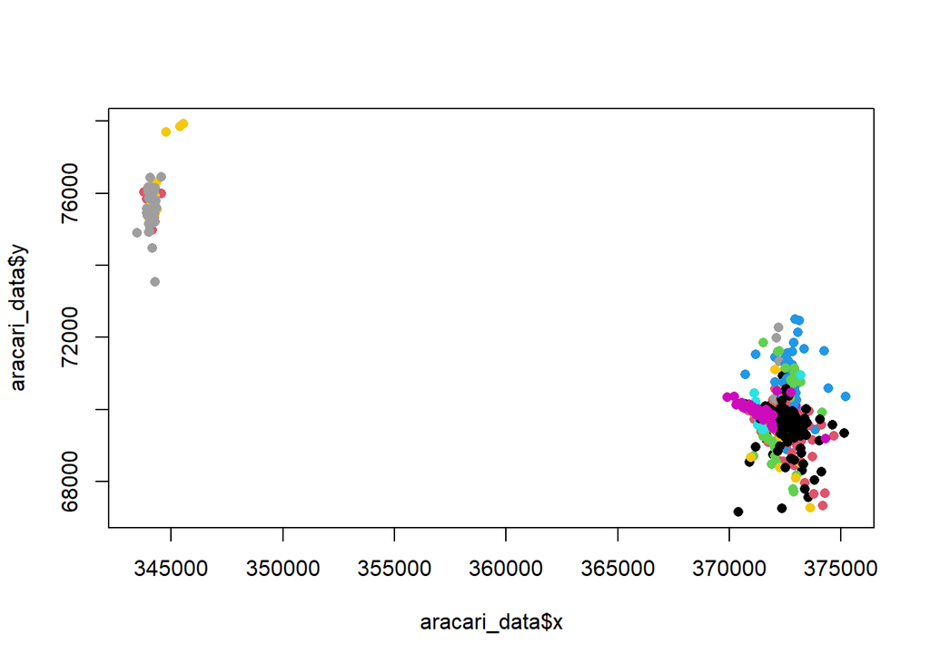

And the individual trajectories for each animal

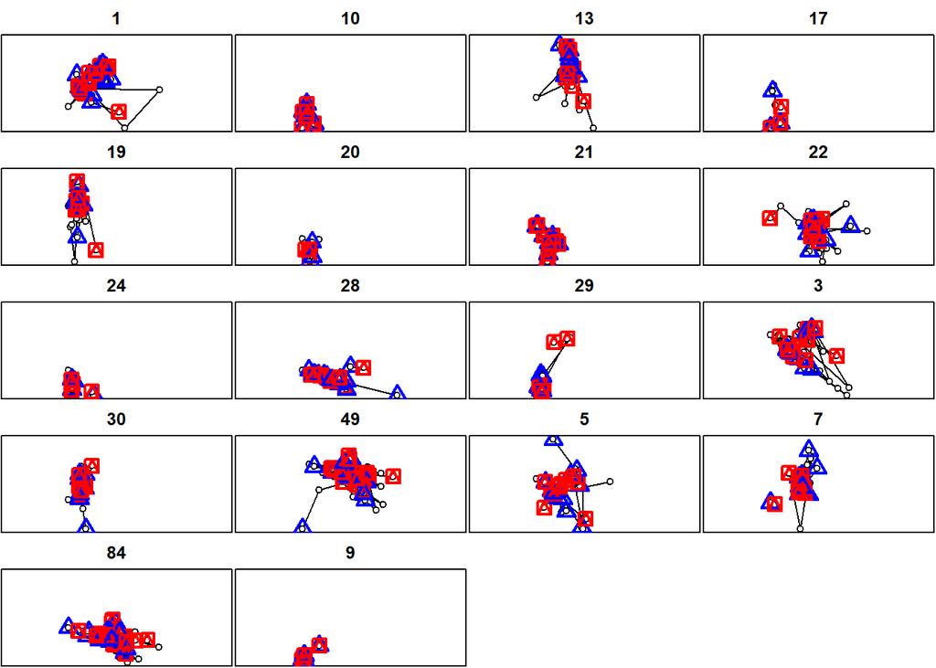

The trajectory for each animal measures [source](https://jamesepaterson.github.io/jamespatersonblog/02_trackingworkshop_trajectories):

- distance,
- dt (the difference in seconds between relocations),
- R2n (the squared distance between the first relocation of the trajectory and the current relocation), and
- two angle measurements (absolute and relative).

We can see the **bursts**, which describe continuous relocations during the same tracking session, which in this case is one day for four hours. Tracking periods are 4-6 daylight hours, with individual bird locations recorded every 15 minutes. Although, not always possible to get a reading every 15 minutes, some have other intervals. Tracking alternates between morning and afternoon to capture daily variation in movement.

- So, there is sampling error. A success/failure of capturing a signal every 15 minutes in those 4-6hours.
- And, there are multiple tracking periods, each tracking period represented by a “burst”

```
##
## *********** List of class ltraj ***********
##
## Type of the traject: Type II (time recorded)
## * Time zone: UTC *
## Irregular traject. Variable time lag between two locs
##
## Characteristics of the bursts:
##   id       burst nb.reloc NAs          date.begin            date.end
## 1  1 1 14-Jan-03        1   0 2003-01-14 07:00:00 2003-01-14 07:00:00
## 2  1 1 14-Mar-03        1   0 2003-03-14 06:15:00 2003-03-14 06:15:00
## 3  1 1 16-Jan-03        2   0 2003-01-16 06:15:00 2003-01-16 06:45:00
## 4  1 1 18-Feb-03        4   0 2003-02-18 06:15:00 2003-02-18 07:45:00
## 5  1 1 20-Dec-02        2   0 2002-12-20 08:00:00 2002-12-20 08:30:00
## 6  1 1 20-Feb-03        1   0 2003-02-20 07:00:00 2003-02-20 07:00:00
##
##
##  infolocs provided. The following variables are available:
## [1] "pkey"
```

```
##    id nbursts nlocs
## 1  10      NA     7
## 2   9      NA     8
## 3  17       3    10
## 4  21      NA    14
## 5  24       3    14
## 6  20       4    26
## 7  29       6    38
## 8  22       9    53
## 9   5      10    53
## 10 28      15    55
## 11 30       8    56
## 12  1      13    59
## 13 19       7    62
## 14 13       7    67
## 15  7      12    84
## 16  3      16    93
## 17 84      20   100
## 18 49      19   108
```

```
##  [1] 1  10 13 17 19 20 21 22 24 28 29 3  30 49 5  7  84 9
## Levels: 1 10 13 17 19 20 21 22 24 28 29 3 30 49 5 7 84 9
```

```
##    id distperday       sd
## 1   1   43262.23 56936.91
## 2  13   44982.00 56806.96
## 3  17   19044.07 32590.90
## 4  19   39380.34 45015.91
## 5  20   17330.35 12603.11
## 6  22   40049.73 45059.82
## 7  24   26410.71 27056.76
## 8  28   17823.80 31280.87
## 9  29   30144.97 51441.13
## 10  3   60280.01 67491.84
## 11 30   19587.57 26346.00
## 12 49   26944.05 29336.79
## 13  5   67819.89 63500.80
## 14  7   36028.55 39747.04
## 15 84   24563.73 25881.79
```

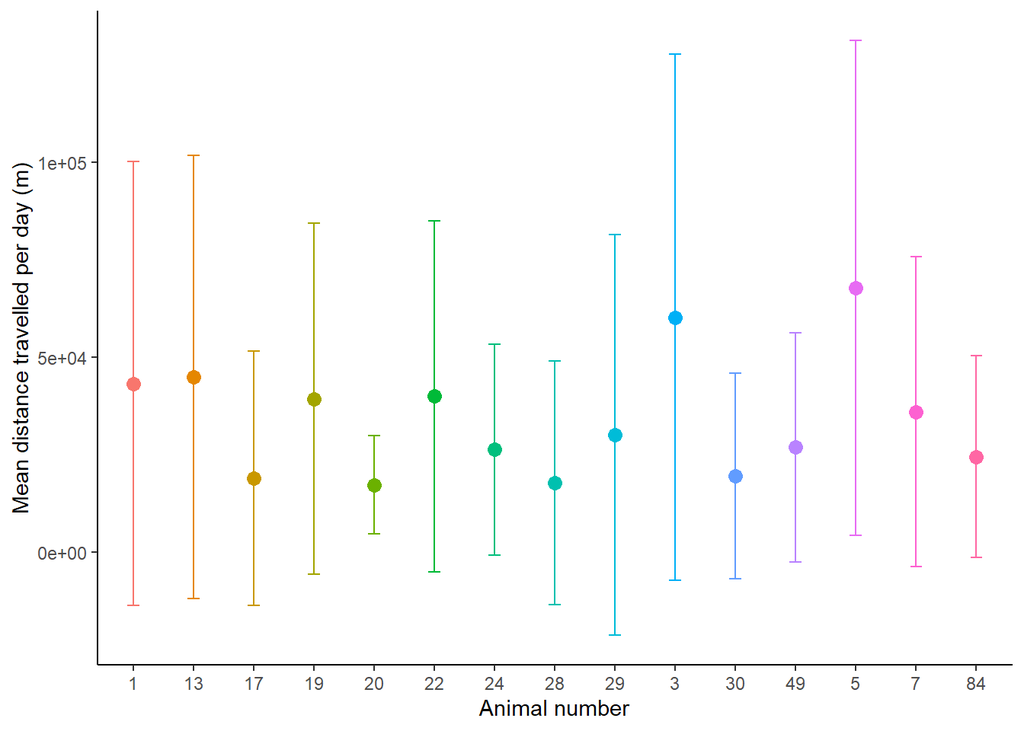

### References

Holbrook, Kimberly M. 2011. “Home Range and Movement Patterns of Toucans: Implications for Seed Dispersal.” *Biotropica* 43 (3): 357–64.

Holbrook, KM, BA Loiselle, and others. 2007. “Using Toucan-Generated Dispersal Models to Estimate Seed Dispersal in Amazonian Ecuador.” *Seed Dispersal: Theory and Its Application in a Changing World*, 300–321.